# Relationship Between School Staffing and Student Suspensions, Referrals, and Arrests

Manuel V. Cano

Errol Kaylor

Havisha Khurana

Merly Klaas

Cassie N. Malcom

# Abstract

School staffing choices impact student outcomes. Prior research has explored the association between novice teachers and law enforcement officers on students’ disciplinary actions. This study uses publicly available data on schools from the 2017-18 Civil Rights Data Collection (n = 97,632). We had two research questions that aimed to answer how school staffing affects school climate. To study the relationship between novice teachers and student rates of suspensions, we used a 3-level hierarchical linear model (HLM) with schools nested within districts and districts nested within states. We also used a multiple regression with one continuous and two categorical predictors to find the association between law enforcement officials and student arrests and referrals. In both cases, the relationship was statistically significant even after controlling for characteristics. We also noted that males and Black students receive more disciplinary actions. Our results indicate that new teachers may benefit from additional classroom management training. In addition, alternative methods of encouraging proper student behavior should be considered.

# Introduction

## Prior Literature

Previous research has shown that school staffing choices can have an impact on student outcomes. In particular, novice teachers and law enforcement officials located on school campuses may impact negatively the number of disciplinary actions taken with students of various subgroups. Often, poor classroom management by novice teachers leads to them sending more students to the school office for a form of disciplinary action (e.g., referrals, suspensions, and even arrests) (Williams et al. 2020). Less research has been done on how law enforcement officials impact student disciplinary outcomes, but there have been some studies that suggest there are both benefits (i.e., deterring student to student assaults) and costs (i.e., more students reported for “non-serious violent crimes”) (James and McCallion 2013).

The relationship between student disciplinary outcomes and number of new teachers has several potential mechanisms. In addition to poor classroom management, schools with a higher level of new teachers may lack in senior leadership, giving new teachers fewer opportunities to improve their teaching. Our study also looks for a similar relationship between law enforcement presence and student discipline, where higher LEO presence affects how students act and teachers respond.

## Research Questions

Our team developed two research questions in order to determine if school staffing choices are related to student disciplinary outcomes.

**RQ1. What is the relationship between school level rates of novice teachers and school level rates of student suspensions?**

1. Descriptively, how do rates of exclusionary discipline differ by gender and race/ethnicity?

**RQ2. What is the relationship between the number of full time equivalent (FTE) law enforcement officials (both law enforcement officers and security guards) and the total combined number of student referrals and arrests?**

The rest of this document summarizes the methods, results, and ends with a discussion of each research question.

# Methods

## Sample and Exclusion Criteria

This analysis was conducted using publicly available data from the 2017-18 civil rights data collection. Each biennium, schools across the United States are required to respond and report key information about their school across a range of topics. This study uses the data in the following areas:

1. School Support (count of enrolled novice teachers, sworn law enforcement officers (LEOs), and security guards)
2. Referrals & Arrests (count of referrals and arrests of students by subgroup, which includes gender and disability status)
3. Suspensions and Expulsions (count of suspensions and expulsions of students by subgroup)
4. Enrollment (count of enrolled students by subgroup)
5. School characteristics (type: magnet, alternate, charter, and special education)
6. Data sets are organized by state, school district (LEA), and school level

**Table 1. Summary Statistics**

| **Characteristic** | **N = 96,853**<sup>1</sup> |
| --- | --- |
| White Students Enrollment (%) | 51 (33) |
| Hispanic Students Enrollment (%) | 24 (28) |
| Black Students Enrollment (%) | 15 (23) |
| Asian Students Enrollment (%) | 3.8 (8.3) |
| Native American/Alaskan Students Enrollment (%) | 1.72 (8.50) |
| Hawaiian and Pacific Islander Students Enrollment (%) | 0.35 (2.27) |
| Two or more races Student Enrollment (%) | 3.8 (4.2) |
| Students with Disability Status Enrollment (%) | 15 (14) |
| Novice Teacher Enrolled (%) | 12 (14) |
| Law Enforcement Officials | 34 (26) |
| Suspension Rate | 53 (101) |
| Explusion Rate | 1 (6) |
| Number of Arrest | 1 (6) |
| Number of Referral | 2 (11) |

<sup>*1*</sup> Mean (SD) per school

We used R [Version 4.0.4; R Core Team (2021)] and the R-packages *broom.mixed* [Version 0.2.7; Bolker and Robinson (2021)], *car* [Version 3.0.12; Fox and Weisberg (2019); Fox, Weisberg, and Price (2020)], *carData* [Version 3.0.4; Fox, Weisberg, and Price (2020)], *dplyr* [Version 1.0.7; Wickham et al. (2021)], *forcats* [Version 0.5.1; Wickham (2021a)], *ggplot2* [Version 3.3.5; Wickham (2016)], *ggridges* [Version 0.5.3; Wilke (2021)], *ggstance* [Version 0.3.5; Henry, Wickham, and Chang (2020)], *ggthemes* [Version 4.2.4; Arnold (2021)], *gtsummary* [Version 1.5.0; Sjoberg et al. (2021)], *here* [Version 1.0.1; Müller (2020)], *janitor* [Version 2.1.0; Firke (2021)], *jtools* [Version 2.1.4; Long (2020)], *lm.beta* [Version 1.5.1; Behrendt (2014)], *lme4* [Version 1.1.27.1; Bates et al. (2015)], *Matrix* [Version 1.3.2; Bates and Maechler (2021)], *papaja* [Version 0.1.0.9997; Aust and Barth (2020)], *performance* [Version 0.8.0; Lüdecke et al. (2021)], *psych* [Version 2.1.9; Revelle (2021)], *purrr* [Version 0.3.4; Henry and Wickham (2020)], *readr* [Version 2.1.1; Wickham and Hester (2021)], *reshape2* [Version 1.4.4; Wickham (2007)], *rio* [Version 0.5.29; Chan et al. (2021)], *sjmisc* [Version 2.8.9; Lüdecke (2018)], *sjPlot* [Version 2.8.10; Lüdecke (2021)], *skimr* [Version 2.1.3; Waring et al. (2021)], *stringr* [Version 1.4.0; Wickham (2019)], *tibble* [Version 3.1.6; Müller and Wickham (2021)], *tidyr* [Version 1.1.4; Wickham (2021b)], and *tidyverse* [Version 1.3.1; Wickham et al. (2019)] for all our analyses.

## Outcome Measures and Predictors of Interest

The main predictor variable for research question one was the percent of teachers that are novice teachers at a school. A teacher was considered novice if they were in their first or second year of teaching. This variable was calculated by dividing the total FTE of novice teachers at a school by the total FTE of full time teachers. Across schools in our sample, the mean rate of novice teachers was 12.0189315, and the numbers ranged from 0 to 100. There was wide variation in the rate of novice teachers within and across states. In our sample, Florida had the highest rate of novice teachers while North Carolina had the lowest rate (see Figure 1 in the appendix).

The main predictor of interest for research question two was the number of law enforcement officials (sworn law enforcement officers and security guards). This variable was calculated by summing the total FTE of sworn law enforcement officers and security guards to get a count.

For research question 2, the outcome measure of interest was the total number of disciplinary actions. The total number of disciplinary actions was determined by adding the number of student referrals and arrests for each district.

## Analytic Approach

Descriptive statistics and regression analyses were used to answer the two research questions. To answer the first research question, we used a 3-level hierarchical linear model (HLM) with schools nested within districts and districts nested within states. The final model is represented by the following sets of equations.

$$Y_{jks}= \pi_{0ks} + X_j + \pi_{1ks}*noviceteachers+ \varepsilon _{jks}$$
$$\pi_{ks}=\beta_{00s}+ r_{0jk}$$
$$\pi_{1ks}=\beta_{01s}+ r_{1jk}$$
$$\beta_{00s}= \gamma_{000}+ \mu_{00k}$$
$$\beta_{01s}= \gamma_{100}$$

To answer the second research question, we used a multiple regression with one continuous and two categorical predictors. The continuous predictor was total number of law enforcement officials and the categorical variables included gender and disability status. Gender was coded so that **female** was 0 and disability status was coded so that students **with** a disability were 0.

# Results

## Research Question 1 - Rates of Novice Teachers and Suspensions

Rates of novice teachers was positively and statistically significantly associated with higher rates of suspensions. Across schools in the United States, the model estimated average rate of suspension was 104 students per 1000 students at typical schools (e.g. not an alternative, charter, or magnet school) with average rates of total enrollment and average rates of enrollment by race/ethnicity, EL students, and special education enrollment. A one percentage point increase in the rate of novice teachers increased the number of students suspended per 1000 students by 1 (see table 1 in the appendix). Similar estimates were found across model specifications including a simpler HLM model with no added covariates and a 3 level random intercept and slopes model with interactions between rates of novice teachers and rate of black and special education students.

Figure 1. Estimated relationship between rate of novice teachers and student suspension rates across model specification

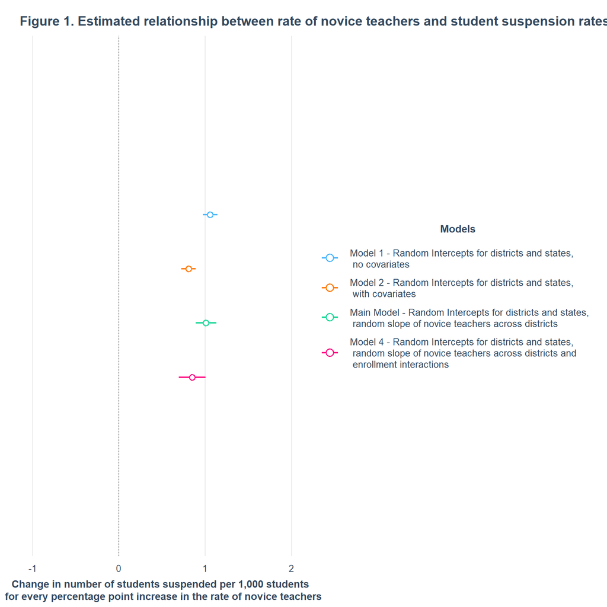

## Research Question 1 - Descriptive Results

Figure 2. Suspension Rate in Preschool shows that, **Black pre-school students** accounted for 15% of total student population, but received 17-25% of one or more out of school suspensions. In comparison, white students represent lower range suspension rate, between 15-21% of students suspended, while accounted for 51% of total student population.

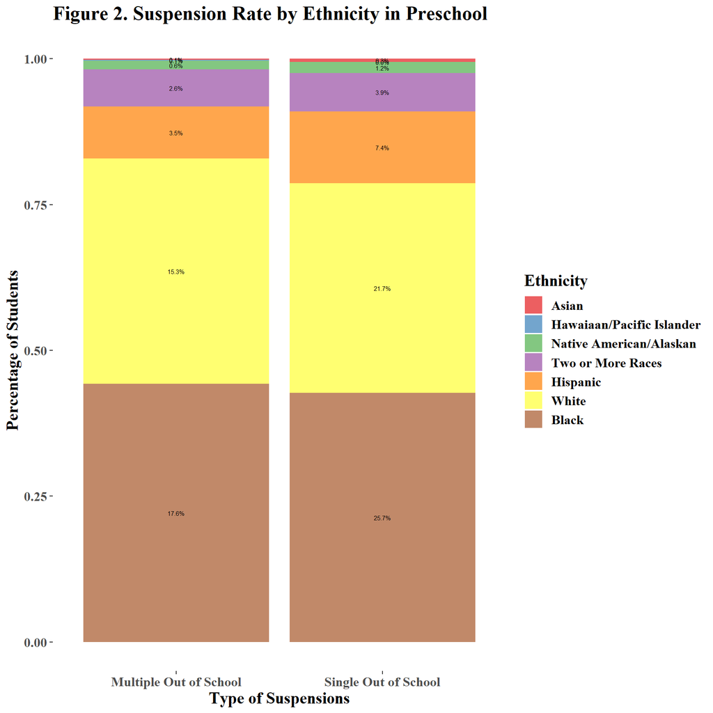

Figure 3. Suspension Rate in K12 shows that, Black students in K12 accounted for 15% of the total student population, but accounted for 16-21% of students who were receiving one or more suspension. In comparison, white students also represent similar range of between 10-22% of students suspended, while accounted for 51% of total student population.

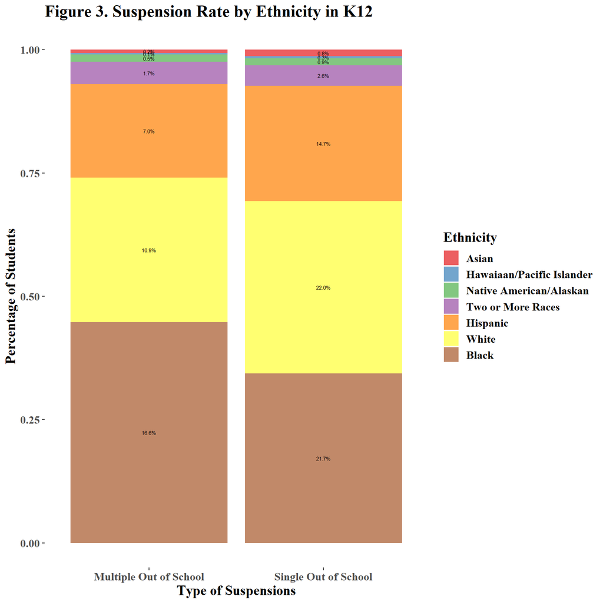

In Figure 4 and Figure 5 when gender was included, both **Black Male** and **Black Female** students were suspended more compared to their peers in Preschool and K-12. Overall, **Male** students were suspended more than female students across all school level.

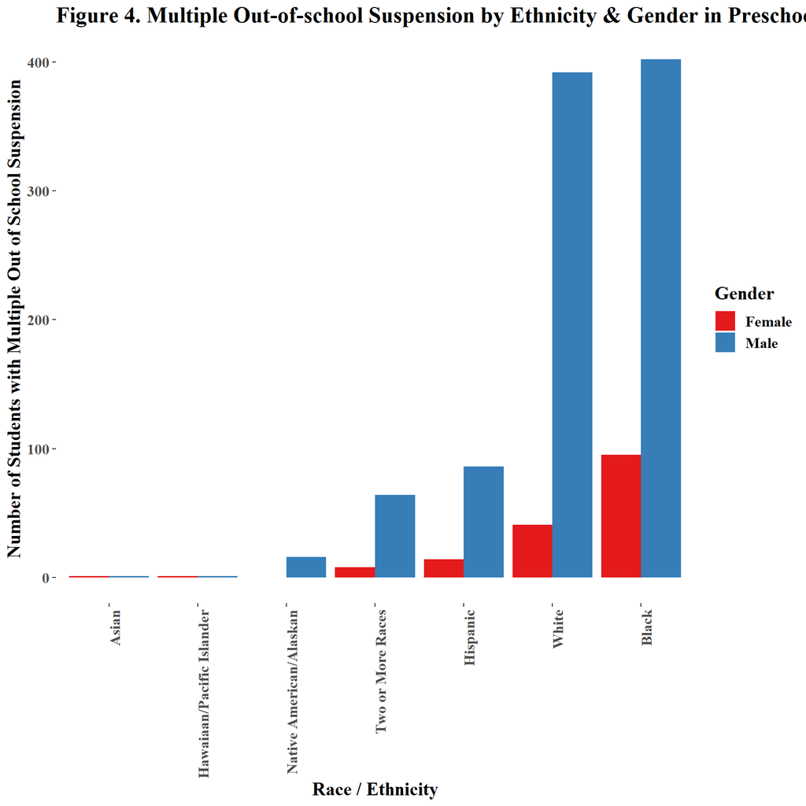

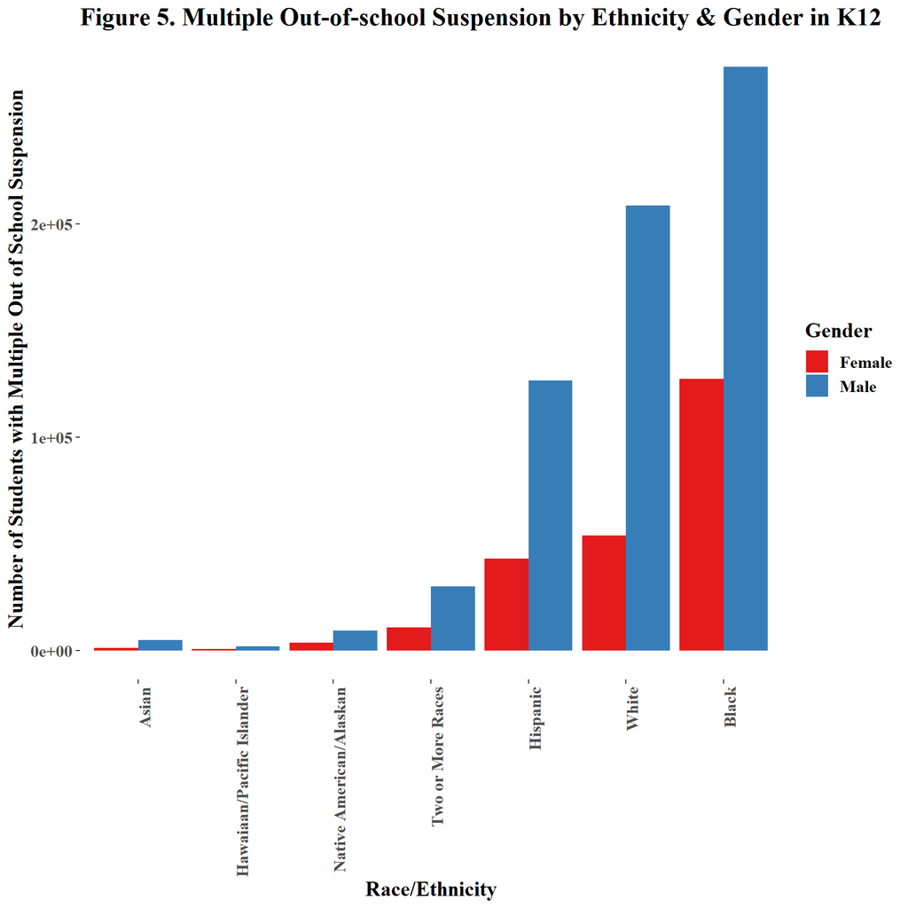

## Research Question 2 - Descriptive Results

Figure 6 displays the total number of student arrests and referrals per state broken down by student gender.

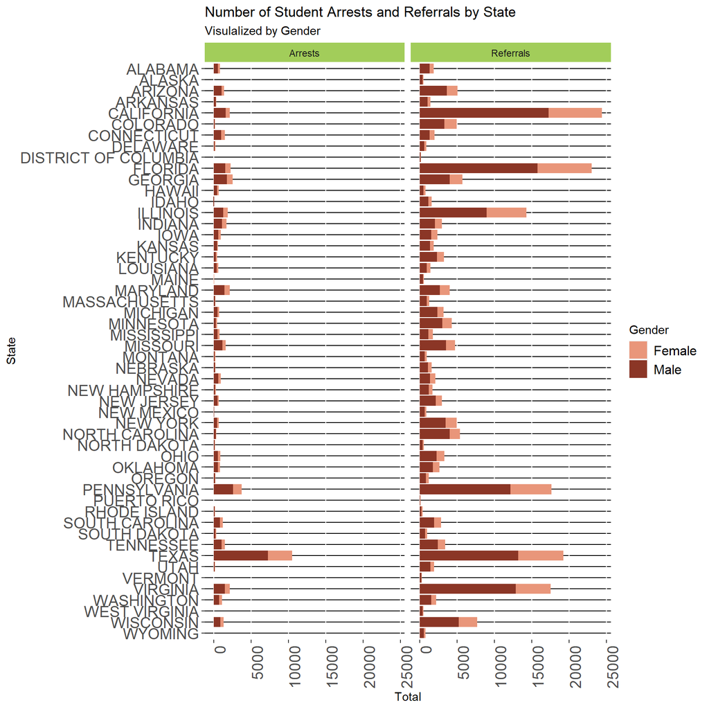

Figure 7 displays the total number of student arrests and referrals per state broken down by student disability status.

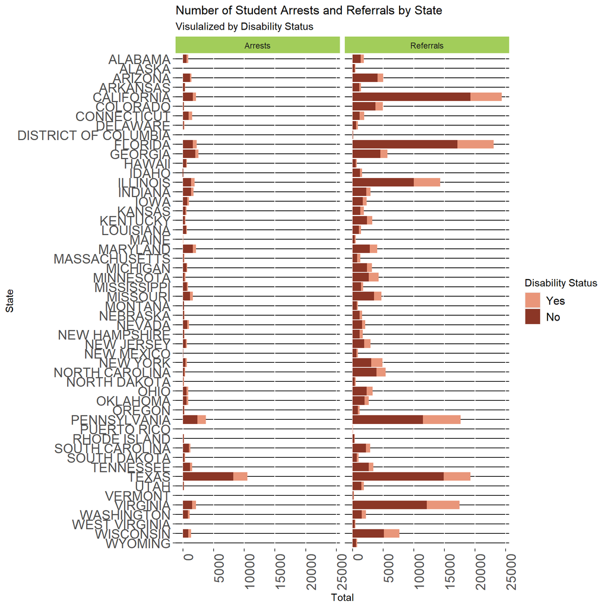

## Research Question 2 - Relationship Between the Total Number of Law Enforcement Officials and Total Number of Student Disciplinary Actions

|  | tot st |  |  |
| --- | --- | --- | --- |
| Predictors | Estimates | CI | p |
| (Intercept) | -0.34 | -0.47 – -0.21 | **<0.001** |
| total law | 0.23 | 0.23 – 0.24 | **<0.001** |
| gender [m] | 1.01 | 0.86 – 1.16 | **<0.001** |
| status [wodis] | 1.14 | 0.98 – 1.29 | **<0.001** |
| Observations | 127292 |  |  |
| R<sup>2</sup> / R<sup>2</sup> adjusted | 0.034 / 0.034 |  |  |

# Discussion

The present study aimed to

1. identify relationships between novice teachers and student suspension rates, and
2. law enforcement official concentration and referrals and arrests.

## New Teachers and Suspensions

Our analysis shows a meaningful relationship between presence of new teachers and student discipline, where more new teachers correlate with more disciplinary actions. This supports our hypothesis that at schools with higher percentages of novice teachers, student disciplinary rates tend to be higher. Our results indicate that new teachers may benefit from additional classroom management training, or for administrators to schedule classroom management trainings when large numbers of new teachers are hired at the same time.

The significant relationship between count of security presence at a school and number of arrests and referrals that occur at a given school should encourage administrators to investigate alternative methods to reducing school violence and ensuring safety of the students.

## Limitations and Future Research

The current study has some shortcomings in regards to applicability of our findings - the school level data does not give a total count of suspensions, only the number of students who had suspensions during the study time. As this data does not break down to specific classrooms, we cannot validate whether more suspensions are happening in classrooms with new teachers specifically. Additionally, our analyses do not examine LEO presence as a proportion of total school staff, but rather as a simple count. Additionally, our analyses includes Juvenile Justice facilities, which tend to have much higher concentrations of law enforcement officers than traditional public schools. A future analysis would benefit from anaylyzing these two groups separately, as well as investigating the cross-section of schools with high LEO presence and novice teacher percent. As our LEO analysis does not look at proportional data, further analysis there is necessary to understand the true significance of LEO and security guard presence on student disciplinary outcomes.

A valuable follow up to this study would be to further contextualize the teacher and LEO employment data with overall school size, funding, and other available data. These analyses would help determine whether student disciplinary outcomes are rising as a result of an unusual or misallocation of school resources, or due to the mechanisms discussed earlier.

# Appendix

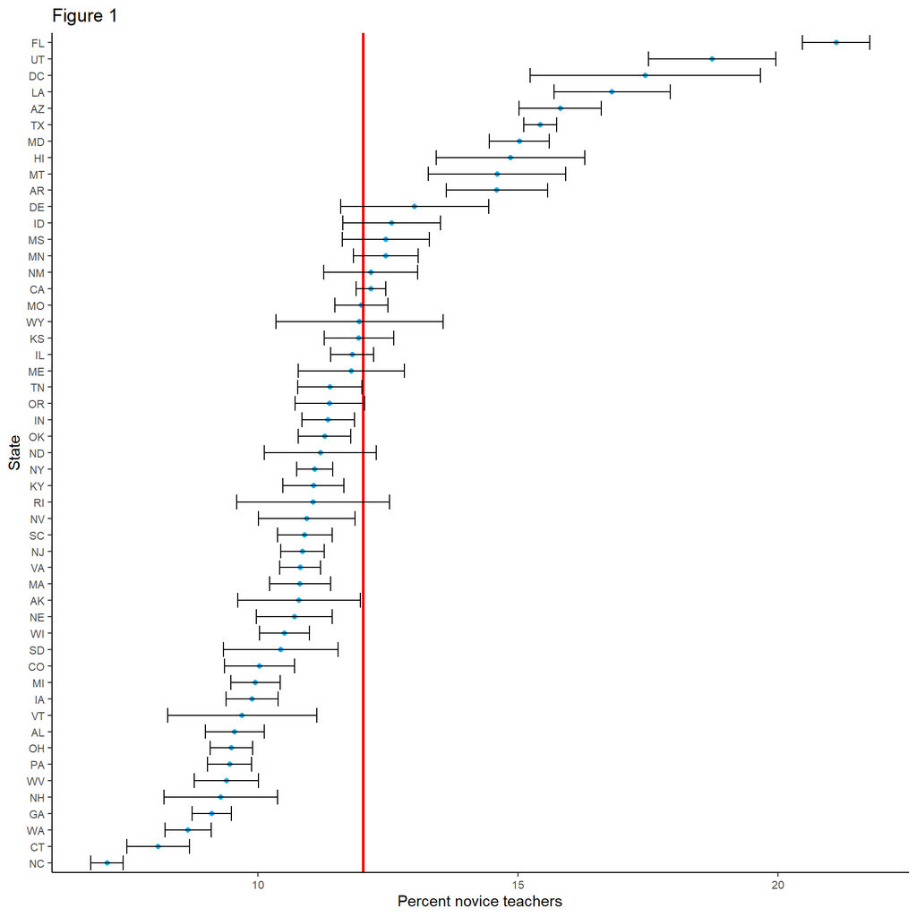

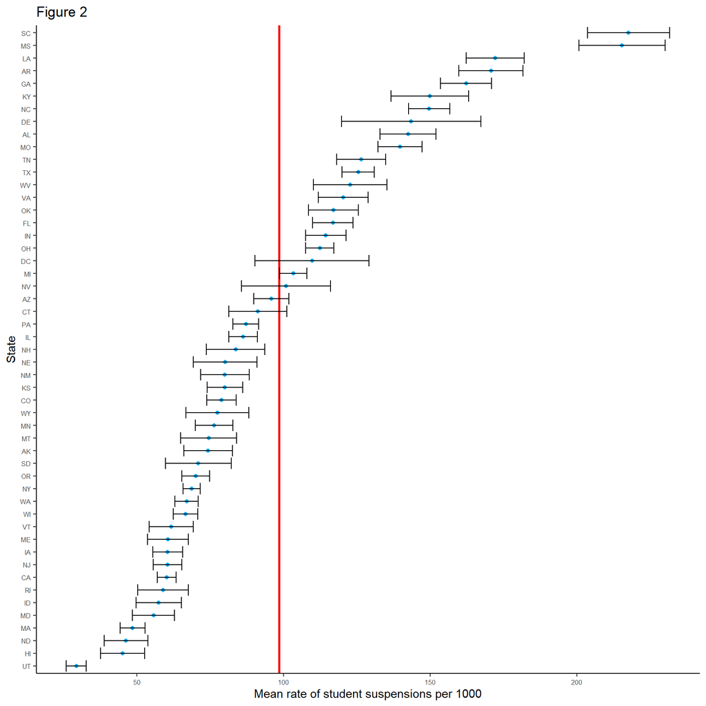

Table 1

Model 1 - Random Intercepts for states and districts, No covariates

Predictors

Estimates

Estimates

Estimates

Estimates

Intercept

98.23 ***  
(85.98 – 110.48)

103.60 ***  
(95.30 – 111.90)

103.77 ***  
(66.04 – 141.49)

101.92 ***  
(64.55 – 139.30)

Percent New Teachers

1.06 ***  
(0.97 – 1.14)

0.81 ***  
(0.72 – 0.89)

1.01 ***  
(0.89 – 1.13)

0.85 ***  
(0.70 – 1.00)

Total Enrollment

0.04 ***  
(0.03 – 0.04)

0.04 ***  
(0.03 – 0.04)

0.04 ***  
(0.03 – 0.04)

Percent American Indian

1.33 ***  
(1.18 – 1.48)

1.37 ***  
(1.21 – 1.52)

1.37 ***  
(1.21 – 1.52)

Percent Asian

-0.75 ***  
(-0.91 – -0.59)

-0.75 ***  
(-0.91 – -0.59)

-0.75 ***  
(-0.90 – -0.59)

Percent Black

2.00 ***  
(1.94 – 2.07)

1.96 ***  
(1.89 – 2.02)

1.90 ***  
(1.82 – 1.98)

Percent Latinx

0.77 ***  
(0.69 – 0.85)

0.78 ***  
(0.70 – 0.86)

0.79 ***  
(0.71 – 0.87)

Percent Hawaiian/Pacific Islander

0.33  
(-0.35 – 1.01)

0.35  
(-0.34 – 1.03)

0.35  
(-0.34 – 1.03)

Percent Multiracial

-0.61 ***  
(-0.90 – -0.32)

-0.60 ***  
(-0.89 – -0.30)

-0.58 ***  
(-0.87 – -0.29)

Percent EL Classified

-1.08 ***  
(-1.19 – -0.97)

-1.13 ***  
(-1.24 – -1.02)

-1.13 ***  
(-1.24 – -1.02)

Percent Special Ed.

1.11 ***  
(1.00 – 1.22)

1.09 ***  
(0.98 – 1.20)

1.04 ***  
(0.92 – 1.16)

Special Ed School (Y/N)

-40.13 ***  
(-50.43 – -29.82)

-40.31 ***  
(-50.58 – -30.04)

-40.80 ***  
(-51.08 – -30.52)

Magnet school (Y/N)

1.36  
(-4.08 – 6.79)

0.96  
(-4.39 – 6.31)

0.96  
(-4.39 – 6.31)

Charter School (Y/N)

-30.50 ***  
(-35.01 – -25.99)

-29.25 ***  
(-33.90 – -24.60)

-29.33 ***  
(-33.98 – -24.68)

Alternative School (Y/N)

219.58 ***  
(213.74 – 225.41)

219.42 ***  
(213.58 – 225.25)

219.38 ***  
(213.55 – 225.22)

Total law enforcement officers

0.00  
(-0.00 – 0.00)

0.00  
(-0.00 – 0.00)

0.00  
(-0.00 – 0.00)

Percent New Teachers X Black Enrollment

0.00 *  
(0.00 – 0.01)

Percent New Teachers X Special Education

0.01 *  
(0.00 – 0.01)

Random Effects

σ<sup>2</sup>

25916.78

23035.48

22071.43

22075.72

τ<sub>00</sub>

2179.06 <sub>leaid</sub>

1686.39 <sub>leaid</sub>

1448.26 <sub>leaid</sub>

1442.48 <sub>leaid</sub>

1915.48 <sub>lea_state</sub>

845.17 <sub>lea_state</sub>

18804.70 <sub>lea_state</sub>

18444.29 <sub>lea_state</sub>

τ<sub>11</sub>

7.57 <sub>leaid.pct_new_teachers_c</sub>

7.54 <sub>leaid.pct_new_teachers_c</sub>

ρ<sub>01</sub>

0.25 <sub>leaid</sub>

0.25 <sub>leaid</sub>

ICC

0.14

0.10

0.50

0.49

N

17145 <sub>leaid</sub>

17144 <sub>leaid</sub>

17144 <sub>leaid</sub>

17144 <sub>leaid</sub>

51 <sub>lea_state</sub>

51 <sub>lea_state</sub>

51 <sub>lea_state</sub>

51 <sub>lea_state</sub>

Observations

95754

95244

95244

95244

Marginal R<sup>2</sup> / Conditional R<sup>2</sup>

0.007 / 0.143

0.158 / 0.241

0.099 / 0.546

0.100 / 0.542

- p<0.05 ** p<0.01 *** p<0.001

# References

Arnold, Jeffrey B. 2021. *Ggthemes: Extra Themes, Scales and Geoms for ’Ggplot2’*. https://CRAN.R-project.org/package=ggthemes.

Aust, Frederik, and Marius Barth. 2020. *papaja: Create APA Manuscripts with R Markdown*. https://github.com/crsh/papaja.

Bates, Douglas, Martin Mächler, Ben Bolker, and Steve Walker. 2015. “Fitting Linear Mixed-Effects Models Using lme4.” *Journal of Statistical Software* 67 (1): 1–48. https://doi.org/10.18637/jss.v067.i01.

Bates, Douglas, and Martin Maechler. 2021. *Matrix: Sparse and Dense Matrix Classes and Methods*. https://CRAN.R-project.org/package=Matrix.

Behrendt, Stefan. 2014. *Lm.beta: Add Standardized Regression Coefficients to Lm-Objects*. https://CRAN.R-project.org/package=lm.beta.

Bolker, Ben, and David Robinson. 2021. *Broom.mixed: Tidying Methods for Mixed Models*. https://CRAN.R-project.org/package=broom.mixed.

Chan, Chung-hong, Geoffrey CH Chan, Thomas J. Leeper, and Jason Becker. 2021. *Rio: A Swiss-Army Knife for Data File i/o*.

Firke, Sam. 2021. *Janitor: Simple Tools for Examining and Cleaning Dirty Data*. https://CRAN.R-project.org/package=janitor.

Fox, John, and Sanford Weisberg. 2019. *An R Companion to Applied Regression*. Third. Thousand Oaks CA: Sage. https://socialsciences.mcmaster.ca/jfox/Books/Companion/.

Fox, John, Sanford Weisberg, and Brad Price. 2020. *carData: Companion to Applied Regression Data Sets*. https://CRAN.R-project.org/package=carData.

Henry, Lionel, and Hadley Wickham. 2020. *Purrr: Functional Programming Tools*. https://CRAN.R-project.org/package=purrr.

Henry, Lionel, Hadley Wickham, and Winston Chang. 2020. *Ggstance: Horizontal ’Ggplot2’ Components*. https://CRAN.R-project.org/package=ggstance.

James, Nathan, and Gail McCallion. 2013. “School Resource Officers: Law Enforcement Officers in Schools.” Congressional Research Service Washington, DC.

Long, Jacob A. 2020. *Jtools: Analysis and Presentation of Social Scientific Data*. https://cran.r-project.org/package=jtools.

Lüdecke, Daniel. 2018. “Sjmisc: Data and Variable Transformation Functions.” *Journal of Open Source Software* 3 (26): 754. https://doi.org/10.21105/joss.00754.

———. 2021. *sjPlot: Data Visualization for Statistics in Social Science*. https://CRAN.R-project.org/package=sjPlot.

Lüdecke, Daniel, Mattan S. Ben-Shachar, Indrajeet Patil, Philip Waggoner, and Dominique Makowski. 2021. “performance: An R Package for Assessment, Comparison and Testing of Statistical Models.” *Journal of Open Source Software* 6 (60): 3139. https://doi.org/10.21105/joss.03139.

Müller, Kirill. 2020. *Here: A Simpler Way to Find Your Files*. https://CRAN.R-project.org/package=here.

Müller, Kirill, and Hadley Wickham. 2021. *Tibble: Simple Data Frames*. https://CRAN.R-project.org/package=tibble.

R Core Team. 2021. *R: A Language and Environment for Statistical Computing*. Vienna, Austria: R Foundation for Statistical Computing. https://www.R-project.org/.

Revelle, William. 2021. *Psych: Procedures for Psychological, Psychometric, and Personality Research*. Evanston, Illinois: Northwestern University. https://CRAN.R-project.org/package=psych.

Sjoberg, Daniel D., Karissa Whiting, Michael Curry, Jessica A. Lavery, and Joseph Larmarange. 2021. “Reproducible Summary Tables with the Gtsummary Package.” *The R Journal* 13: 570–80. https://doi.org/10.32614/RJ-2021-053.

Waring, Elin, Michael Quinn, Amelia McNamara, Eduardo Arino de la Rubia, Hao Zhu, and Shannon Ellis. 2021. *Skimr: Compact and Flexible Summaries of Data*. https://CRAN.R-project.org/package=skimr.

Wickham, Hadley. 2007. “Reshaping Data with the reshape Package.” *Journal of Statistical Software* 21 (12): 1–20. http://www.jstatsoft.org/v21/i12/.

———. 2016. *Ggplot2: Elegant Graphics for Data Analysis*. Springer-Verlag New York. https://ggplot2.tidyverse.org.

———. 2019. *Stringr: Simple, Consistent Wrappers for Common String Operations*. https://CRAN.R-project.org/package=stringr.

———. 2021a. *Forcats: Tools for Working with Categorical Variables (Factors)*. https://CRAN.R-project.org/package=forcats.

———. 2021b. *Tidyr: Tidy Messy Data*. https://CRAN.R-project.org/package=tidyr.

Wickham, Hadley, Mara Averick, Jennifer Bryan, Winston Chang, Lucy D’Agostino McGowan, Romain François, Garrett Grolemund, et al. 2019. “Welcome to the tidyverse.” *Journal of Open Source Software* 4 (43): 1686. https://doi.org/10.21105/joss.01686.

Wickham, Hadley, Romain François, Lionel Henry, and Kirill Müller. 2021. *Dplyr: A Grammar of Data Manipulation*. https://CRAN.R-project.org/package=dplyr.

Wickham, Hadley, and Jim Hester. 2021. *Readr: Read Rectangular Text Data*. https://CRAN.R-project.org/package=readr.

Wilke, Claus O. 2021. *Ggridges: Ridgeline Plots in ’Ggplot2’*. https://CRAN.R-project.org/package=ggridges.

Williams, John A, Jennifer N Johnson, Felicia Dangerfield-Persky, and Courtney G Mayakis. 2020. “Does Employing More Novice Teachers Predict Higher Suspensions for Black Students? A Hierarchical Multiple Regression Analysis.” *The Journal of Negro Education* 89 (4): 448–58.